# Notebook

[output not shown]

[output cut: 95 more lines]

[output not shown]

### Dataset Summary

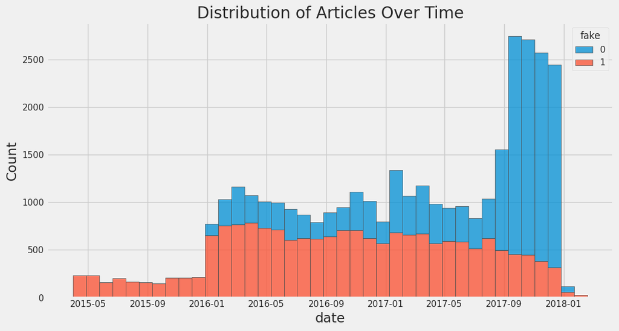

Because of this we should be very careful about using features based on specific keywords or entities.

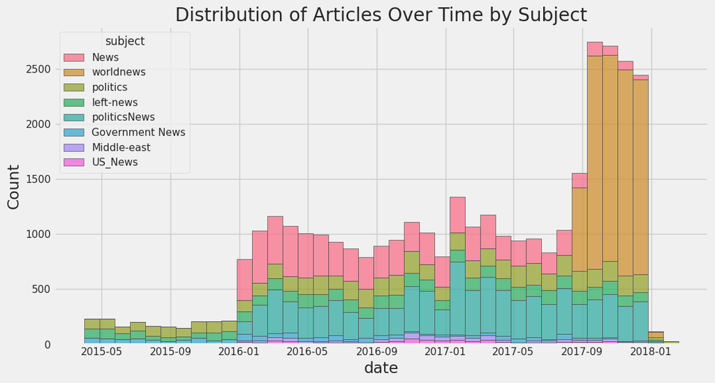

| subject | Fake_Ratio | Total_Count |
| --- | --- | --- |
| Government News | 1.0 | 1205 |
| Middle-east | 1.0 | 616 |
| News | 1.0 | 7343 |
| US_News | 1.0 | 640 |
| left-news | 1.0 | 3478 |
| politics | 1.0 | 5225 |
| politicsNews | 0.0 | 9080 |
| worldnews | 0.0 | 8251 |

The subject field seems to be a subset of the target variable making it completely useless for any model or analysis.

### Semantic Analysis etc.

We've used Spacy and other techniques to generate a set of features based on various semantic and other attributes of each article:

## Lexical Features

`avg_word_length`, `lexical_diversity`, `readability`, `stop_words_ratio`

Measure vocabulary complexity and text readability. Average word length and lexical diversity indicate vocabulary richness, while readability scores (e.g., Flesch Reading Ease) quantify overall text complexity. Stop words ratio reflects the proportion of common functional words, potentially indicating formality or information density.

## Syntactic Features

`pos_ratio_*`, `max_dep_depth`

Capture grammatical structure. POS ratios show distribution of word types (nouns, verbs, etc.), revealing syntactic patterns. Max dependency depth indicates sentence complexity through nesting of grammatical structures.

## Semantic Features

`ner_density`, `avg_token_vector_norm`, `sentiment`

Analyze meaning and content. NER density indicates fact density, average token vector norm (from spaCy's word vectors) suggests semantic richness, and sentiment score captures emotional tone.

## Structural Features

`avg_sent_length`, `median_sent_length`, `std_sent_length`, `punctuation_density`

Describe text organization. Sentence length statistics reveal writing style and complexity. Punctuation density can indicate sentence structure complexity.

## Temporal Features

`verb_tense_ratio_*`

Show time orientation through ratios of past, present, and future tenses. Useful for analyzing narrative focus in news or historical texts.

## Entity Features

`num_*_entities`, `*_entities`

Identify key subjects. Entity counts and types (Person, Organization, Geopolitical Entity) reveal main text subjects. Top entities indicate key players or themes.

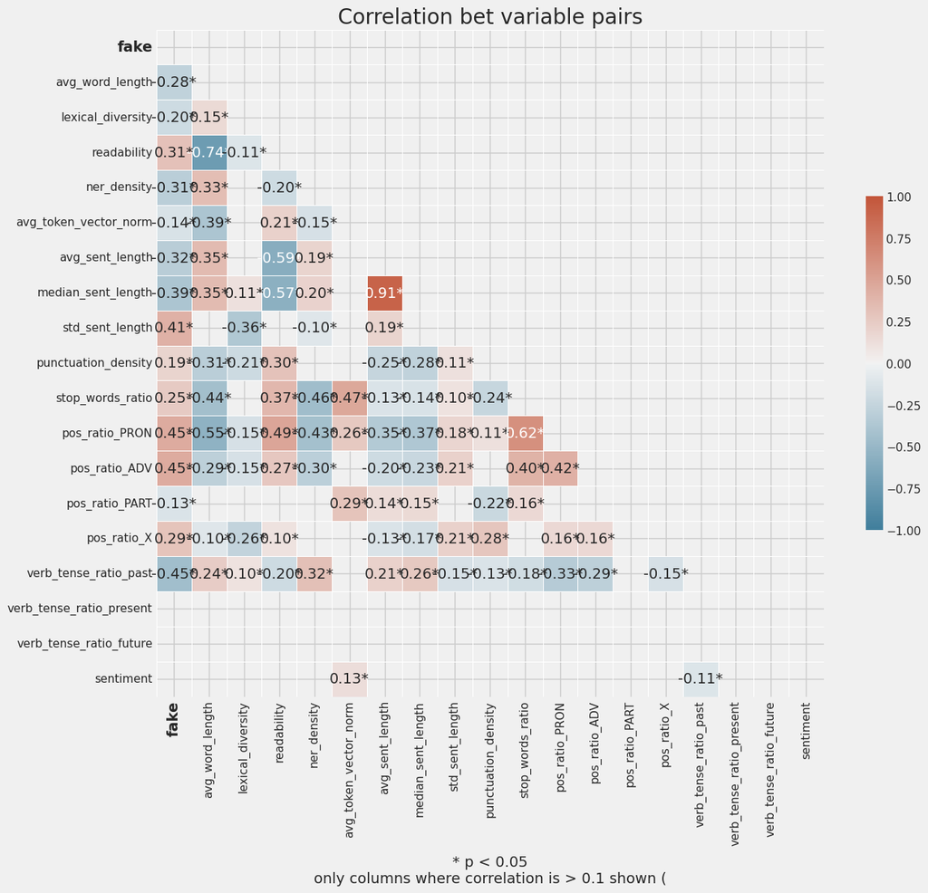

These are all the features that are significantly correlated (p<0.05 and > 0.1 coef) with the target variable:

|  | raw_correlation | abs_correlation |
| --- | --- | --- |
| pos_ratio_PRON | 0.45 | 0.45 |
| pos_ratio_ADV | 0.45 | 0.45 |
| verb_tense_ratio_past | -0.45 | 0.45 |
| std_sent_length | 0.41 | 0.41 |
| median_sent_length | -0.39 | 0.39 |
| avg_sent_length | -0.32 | 0.32 |
| readability | 0.31 | 0.31 |
| ner_density | -0.31 | 0.31 |
| pos_ratio_X | 0.29 | 0.29 |
| avg_word_length | -0.28 | 0.28 |
| stop_words_ratio | 0.25 | 0.25 |
| lexical_diversity | -0.20 | 0.20 |
| punctuation_density | 0.19 | 0.19 |
| avg_token_vector_norm | -0.14 | 0.14 |
| pos_ratio_PART | -0.13 | 0.13 |

We can see that "fake news" articles have a distinctive linguistic patterns compared to Reuters news reports which is not particularly surprising.

They tend to use more pronouns and adverbs, suggesting a more personal and descriptive style. These articles are less likely to use past tense, potentially focusing more on current or future events.

The sentence structure in fake news is characterized by greater variability in length, but with generally shorter sentences overall. This contrasts with legitimate news, which tends to have more consistent and slightly longer sentences.

Fake news articles often have higher readability scores, indicating simpler language, and shorter average word lengths. They also contain fewer named entities (specific people, places, or organizations), suggesting less detailed or fact-based content.

Interestingly, fake news articles are more likely to include unusual words, symbols, or potential grammatical errors. This could indicate less rigorous editing or a more casual writing style.

Again these findings only apply when comparing again articles published by Reuters specifically and not non "fake" news in general.

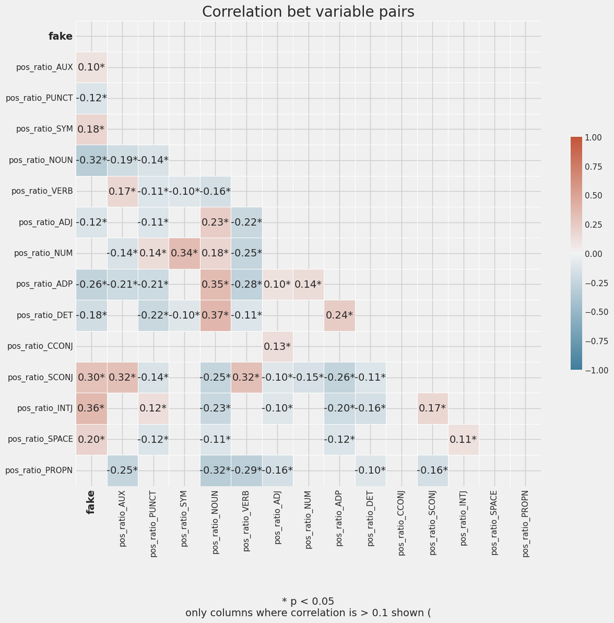

|  | raw_correlation | abs_correlation |
| --- | --- | --- |
| pos_ratio_INTJ | 0.36 | 0.36 |
| pos_ratio_NOUN | -0.32 | 0.32 |
| pos_ratio_SCONJ | 0.30 | 0.30 |
| pos_ratio_ADP | -0.26 | 0.26 |
| pos_ratio_SPACE | 0.20 | 0.20 |
| pos_ratio_SYM | 0.18 | 0.18 |
| pos_ratio_DET | -0.18 | 0.18 |
| pos_ratio_PUNCT | -0.12 | 0.12 |
| pos_ratio_ADJ | -0.12 | 0.12 |
| pos_ratio_AUX | 0.10 | 0.10 |

If we analyze ratios of specific grammatical elements and word types inside both samples, we see some further distinctions:

- Fake news uses more interjections and subordinating conjunctions, likely indicating a more emotive style and possibly more complex sentence structures. However, they employ fewer nouns, adpositions, and determiners, suggesting less specific information.
- They also have higher ratios of spaces and symbols, with slightly more auxiliary verbs, but less punctuation and fewer adjectives. This reinforces the hypothesis of a more informal, emotionally charged style in fake news, with potentially less emphasis on concrete facts compared to Reuters articles.

#### Building a simple model based on semantic features

|  | 0 | 1 | accuracy | macro avg | weighted avg |
| --- | --- | --- | --- | --- | --- |
| precision | 0.972950 | 0.976971 | 0.975021 | 0.974960 | 0.975026 |
| recall | 0.975476 | 0.974595 | 0.975021 | 0.975035 | 0.975021 |
| f1-score | 0.974211 | 0.975781 | 0.975021 | 0.974996 | 0.975022 |
| support | 3466.000000 | 3700.000000 | 0.975021 | 7166.000000 | 7166.000000 |

We can see that we can build a relatively accurate model based on linguistic and stylometric features that were built with Spacy without actually looking at the actual content of the articles themselves.

```
150
```

### Entity Analysis

Next we'll look into the actual content of the articles. We've used spacy to extract specific entities that were used in articles (specifically names of persons, geographic locations and organizations).

150 new features (50 for each category) were generated based on the most frequently referenced entities in all samples:

#### Most Popular Entities

We'll start with a temporal analysis of the most popular entities:

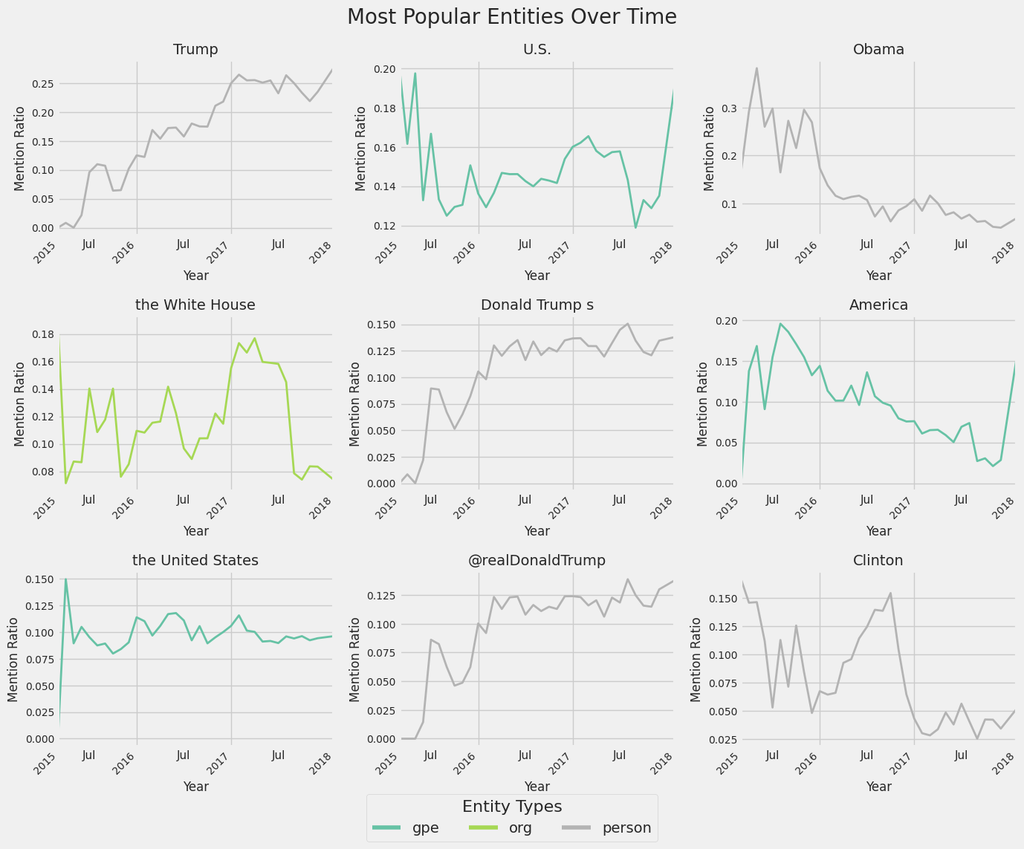

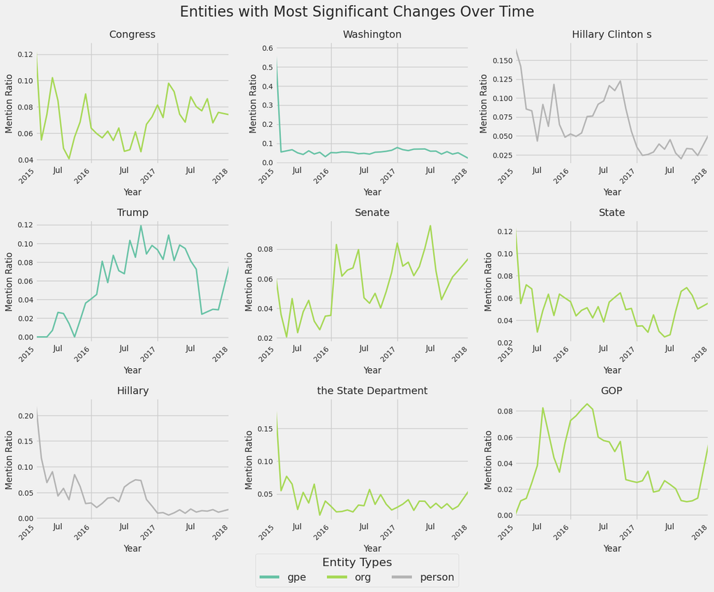

| entity entity_type date | @realDonaldTrump person | Assad person | Bannon person | Biden person | Brown person | Bush person | Carson person | Clinton person | Comey person | Conway person | ... | Texas gpe | Trump gpe | Turkey gpe | U.S. gpe | UK gpe | Ukraine gpe | Virginia gpe | Washington gpe | Yemen gpe | the United States gpe |
| --- | --- | --- | --- | --- | --- | --- | --- | --- | --- | --- | --- | --- | --- | --- | --- | --- | --- | --- | --- | --- | --- |
| 2015-03 | 0.000000 | 0.000000 | 0.000000 | 0.055556 | 0.055556 | 0.000000 | 0.000000 | 0.166667 | 0.000000 | 0.000000 | ... | 0.000000 | 0.000000 | 0.000000 | 0.200000 | 0.000000 | 0.000000 | 0.000000 | 0.600000 | 0.000000 | 0.000000 |
| 2015-04 | 0.000000 | 0.000000 | 0.000000 | 0.008333 | 0.054167 | 0.016667 | 0.012500 | 0.145833 | 0.000000 | 0.004167 | ... | 0.030879 | 0.000000 | 0.004751 | 0.161520 | 0.009501 | 0.009501 | 0.009501 | 0.054632 | 0.007126 | 0.149644 |
| 2015-05 | 0.000000 | 0.000000 | 0.000000 | 0.020325 | 0.024390 | 0.028455 | 0.012195 | 0.146341 | 0.000000 | 0.000000 | ... | 0.060526 | 0.000000 | 0.007895 | 0.197368 | 0.005263 | 0.002632 | 0.002632 | 0.060526 | 0.005263 | 0.089474 |
| 2015-06 | 0.014440 | 0.000000 | 0.000000 | 0.003610 | 0.032491 | 0.014440 | 0.003610 | 0.111913 | 0.000000 | 0.000000 | ... | 0.062937 | 0.006993 | 0.003497 | 0.132867 | 0.010490 | 0.000000 | 0.010490 | 0.066434 | 0.000000 | 0.104895 |
| 2015-07 | 0.086093 | 0.006623 | 0.000000 | 0.000000 | 0.023179 | 0.039735 | 0.013245 | 0.052980 | 0.000000 | 0.000000 | ... | 0.021429 | 0.026190 | 0.002381 | 0.166667 | 0.004762 | 0.000000 | 0.014286 | 0.050000 | 0.004762 | 0.095238 |
| 2015-08 | 0.082317 | 0.003049 | 0.006098 | 0.024390 | 0.033537 | 0.027439 | 0.006098 | 0.112805 | 0.000000 | 0.000000 | ... | 0.054167 | 0.025000 | 0.000000 | 0.133333 | 0.008333 | 0.000000 | 0.016667 | 0.041667 | 0.000000 | 0.087500 |
| 2015-09 | 0.062500 | 0.031250 | 0.000000 | 0.026786 | 0.008929 | 0.013393 | 0.026786 | 0.071429 | 0.000000 | 0.004464 | ... | 0.057143 | 0.014286 | 0.007143 | 0.125000 | 0.000000 | 0.000000 | 0.007143 | 0.060714 | 0.000000 | 0.089286 |
| 2015-10 | 0.046154 | 0.007692 | 0.000000 | 0.035897 | 0.010256 | 0.038462 | 0.023077 | 0.125641 | 0.007692 | 0.000000 | ... | 0.024793 | 0.000000 | 0.002755 | 0.129477 | 0.008264 | 0.008264 | 0.016529 | 0.044077 | 0.005510 | 0.079890 |
| 2015-11 | 0.048701 | 0.016234 | 0.000000 | 0.003247 | 0.006494 | 0.025974 | 0.019481 | 0.084416 | 0.003247 | 0.009740 | ... | 0.039823 | 0.017699 | 0.026549 | 0.130531 | 0.006637 | 0.002212 | 0.002212 | 0.053097 | 0.002212 | 0.084071 |
| 2015-12 | 0.062323 | 0.008499 | 0.000000 | 0.011331 | 0.002833 | 0.016997 | 0.011331 | 0.048159 | 0.011331 | 0.002833 | ... | 0.008032 | 0.036145 | 0.008032 | 0.150602 | 0.006024 | 0.002008 | 0.008032 | 0.030120 | 0.008032 | 0.090361 |
| 2016-01 | 0.100234 | 0.000937 | 0.001405 | 0.011241 | 0.006557 | 0.043560 | 0.010304 | 0.067447 | 0.000000 | 0.000000 | ... | 0.043162 | 0.040562 | 0.004160 | 0.136245 | 0.007800 | 0.000000 | 0.010920 | 0.051482 | 0.002080 | 0.113885 |
| 2016-02 | 0.091929 | 0.000362 | 0.000000 | 0.008686 | 0.006515 | 0.042345 | 0.022801 | 0.064423 | 0.000724 | 0.000362 | ... | 0.061252 | 0.045372 | 0.002722 | 0.129310 | 0.002269 | 0.001815 | 0.015880 | 0.050363 | 0.001361 | 0.110254 |
| 2016-03 | 0.123330 | 0.002784 | 0.000000 | 0.003898 | 0.008352 | 0.021158 | 0.007795 | 0.065980 | 0.001949 | 0.001114 | ... | 0.046479 | 0.080819 | 0.001734 | 0.136663 | 0.004509 | 0.003469 | 0.010753 | 0.054804 | 0.002081 | 0.096774 |
| 2016-04 | 0.112870 | 0.004060 | 0.000812 | 0.003654 | 0.006902 | 0.018676 | 0.006496 | 0.092570 | 0.002030 | 0.000406 | ... | 0.050219 | 0.058020 | 0.003901 | 0.146758 | 0.000975 | 0.005851 | 0.016090 | 0.054120 | 0.002925 | 0.105802 |
| 2016-05 | 0.122956 | 0.000000 | 0.000654 | 0.002943 | 0.007521 | 0.016351 | 0.005559 | 0.095814 | 0.000981 | 0.000327 | ... | 0.027764 | 0.087189 | 0.001948 | 0.146128 | 0.009255 | 0.001461 | 0.021919 | 0.051632 | 0.001461 | 0.116902 |
| 2016-06 | 0.123615 | 0.002424 | 0.000693 | 0.005194 | 0.007964 | 0.013504 | 0.001039 | 0.114266 | 0.003463 | 0.000000 | ... | 0.024861 | 0.070724 | 0.003429 | 0.146164 | 0.012002 | 0.000857 | 0.011144 | 0.045435 | 0.003429 | 0.117874 |
| 2016-07 | 0.107921 | 0.001038 | 0.001038 | 0.005189 | 0.010031 | 0.015220 | 0.004151 | 0.124524 | 0.010723 | 0.000346 | ... | 0.038732 | 0.067488 | 0.004108 | 0.142606 | 0.004695 | 0.006455 | 0.022887 | 0.047535 | 0.000587 | 0.110915 |
| 2016-08 | 0.116339 | 0.000645 | 0.006123 | 0.004834 | 0.004834 | 0.013858 | 0.003223 | 0.139542 | 0.003867 | 0.005801 | ... | 0.014475 | 0.103136 | 0.002413 | 0.139928 | 0.003619 | 0.007238 | 0.025332 | 0.043426 | 0.001206 | 0.092280 |
| 2016-09 | 0.111041 | 0.003490 | 0.000635 | 0.003173 | 0.003807 | 0.014277 | 0.002538 | 0.138642 | 0.003173 | 0.006980 | ... | 0.015648 | 0.085086 | 0.005379 | 0.143765 | 0.009291 | 0.006357 | 0.013692 | 0.053301 | 0.002934 | 0.105623 |
| 2016-10 | 0.114791 | 0.005976 | 0.000747 | 0.006225 | 0.000996 | 0.016434 | 0.001245 | 0.154382 | 0.012201 | 0.003735 | ... | 0.016835 | 0.118807 | 0.005772 | 0.142857 | 0.001924 | 0.008658 | 0.019240 | 0.054834 | 0.003367 | 0.089466 |
| 2016-11 | 0.112899 | 0.004734 | 0.010651 | 0.001657 | 0.002130 | 0.020118 | 0.005207 | 0.104615 | 0.008994 | 0.009467 | ... | 0.016196 | 0.088560 | 0.004135 | 0.141626 | 0.008959 | 0.013784 | 0.012750 | 0.058236 | 0.001723 | 0.095107 |
| 2016-12 | 0.123891 | 0.004006 | 0.009442 | 0.002289 | 0.008298 | 0.023176 | 0.008870 | 0.064664 | 0.004578 | 0.009442 | ... | 0.017268 | 0.097724 | 0.005102 | 0.153846 | 0.004710 | 0.009027 | 0.010204 | 0.063579 | 0.003925 | 0.100078 |
| 2017-01 | 0.123987 | 0.003577 | 0.007630 | 0.004053 | 0.004530 | 0.017883 | 0.004530 | 0.043157 | 0.004769 | 0.008345 | ... | 0.011667 | 0.093056 | 0.002500 | 0.160000 | 0.006389 | 0.007222 | 0.007222 | 0.077778 | 0.011944 | 0.105833 |
| 2017-02 | 0.123184 | 0.003196 | 0.021209 | 0.000581 | 0.004067 | 0.019175 | 0.003486 | 0.030215 | 0.001162 | 0.015398 | ... | 0.012123 | 0.082785 | 0.004503 | 0.162106 | 0.005542 | 0.012470 | 0.011431 | 0.066851 | 0.022515 | 0.115691 |
| 2017-03 | 0.115934 | 0.002157 | 0.008088 | 0.001348 | 0.004044 | 0.015638 | 0.004583 | 0.028310 | 0.015368 | 0.007819 | ... | 0.021466 | 0.108808 | 0.006662 | 0.165433 | 0.005922 | 0.008512 | 0.014064 | 0.061806 | 0.010363 | 0.101406 |
| 2017-04 | 0.120399 | 0.028896 | 0.009976 | 0.000688 | 0.000688 | 0.012728 | 0.007568 | 0.033712 | 0.005504 | 0.003440 | ... | 0.013785 | 0.081595 | 0.005589 | 0.157973 | 0.002981 | 0.003726 | 0.007452 | 0.069300 | 0.004471 | 0.100224 |
| 2017-05 | 0.106183 | 0.002590 | 0.004856 | 0.000647 | 0.002590 | 0.012302 | 0.005827 | 0.048559 | 0.071544 | 0.008093 | ... | 0.016997 | 0.098206 | 0.005666 | 0.154863 | 0.001889 | 0.004249 | 0.012748 | 0.069877 | 0.006610 | 0.091124 |
| 2017-06 | 0.122746 | 0.005694 | 0.003164 | 0.003796 | 0.002214 | 0.009807 | 0.004113 | 0.037963 | 0.045555 | 0.008225 | ... | 0.013211 | 0.094476 | 0.002002 | 0.157326 | 0.013611 | 0.004003 | 0.022818 | 0.070456 | 0.008407 | 0.091673 |
| 2017-07 | 0.118481 | 0.004522 | 0.005125 | 0.001206 | 0.002713 | 0.010853 | 0.007235 | 0.056376 | 0.010552 | 0.005427 | ... | 0.011471 | 0.081114 | 0.003277 | 0.157722 | 0.006555 | 0.014338 | 0.015158 | 0.058583 | 0.004916 | 0.089717 |
| 2017-08 | 0.138767 | 0.001836 | 0.017254 | 0.001836 | 0.003671 | 0.012482 | 0.005140 | 0.040749 | 0.005874 | 0.002937 | ... | 0.023238 | 0.072339 | 0.004123 | 0.143178 | 0.004873 | 0.008996 | 0.042354 | 0.059220 | 0.004123 | 0.095952 |
| 2017-09 | 0.124822 | 0.017099 | 0.007125 | 0.001425 | 0.005985 | 0.010544 | 0.003420 | 0.025363 | 0.003990 | 0.000570 | ... | 0.013745 | 0.024247 | 0.029189 | 0.118919 | 0.008340 | 0.009730 | 0.007876 | 0.043707 | 0.007104 | 0.094054 |
| 2017-10 | 0.115757 | 0.014124 | 0.003877 | 0.001662 | 0.004985 | 0.009970 | 0.002215 | 0.042371 | 0.008031 | 0.001385 | ... | 0.008389 | 0.026907 | 0.026749 | 0.132953 | 0.012662 | 0.006173 | 0.007281 | 0.056347 | 0.006331 | 0.096233 |
| 2017-11 | 0.114820 | 0.017623 | 0.004539 | 0.005073 | 0.003204 | 0.008278 | 0.002403 | 0.042190 | 0.006943 | 0.001335 | ... | 0.010010 | 0.029545 | 0.021311 | 0.128834 | 0.010010 | 0.011947 | 0.008072 | 0.043429 | 0.017275 | 0.092347 |
| 2017-12 | 0.129933 | 0.013965 | 0.003339 | 0.000607 | 0.001214 | 0.010018 | 0.003339 | 0.034305 | 0.010929 | 0.001214 | ... | 0.005868 | 0.028975 | 0.022006 | 0.135155 | 0.012654 | 0.013204 | 0.005868 | 0.050614 | 0.012654 | 0.094260 |
| 2018-02 | 0.137931 | 0.000000 | 0.000000 | 0.000000 | 0.000000 | 0.000000 | 0.017241 | 0.051724 | 0.000000 | 0.000000 | ... | 0.019231 | 0.076923 | 0.000000 | 0.192308 | 0.000000 | 0.000000 | 0.000000 | 0.019231 | 0.000000 | 0.096154 |

35 rows × 150 columns

We can see some were clear patterns, e.g. the lead up to the 2016 elections is highly visible:

- Mentions of Barrack Obama are relatively frequent initially but start decreasing signficantly at the end of this term
- Mentions of Donald Trump were growing almost continuously prior to the election, whereas Hillary Clinton start off at a very high level (being the presumed Democrat nomine for a while prior to the elections) and then more or less completely collapse after she loses to Trump.

### Only Entities in "Fake News" Articles

We'll filter out Reuters articles and try to check if there are any clear topic related patterns only in fake samples.

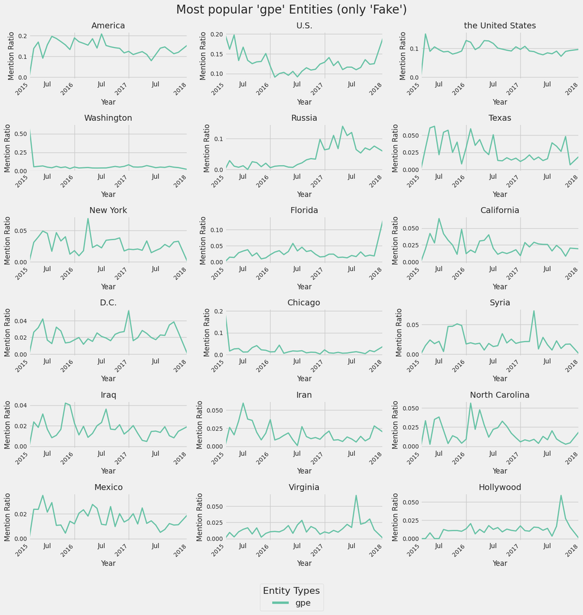

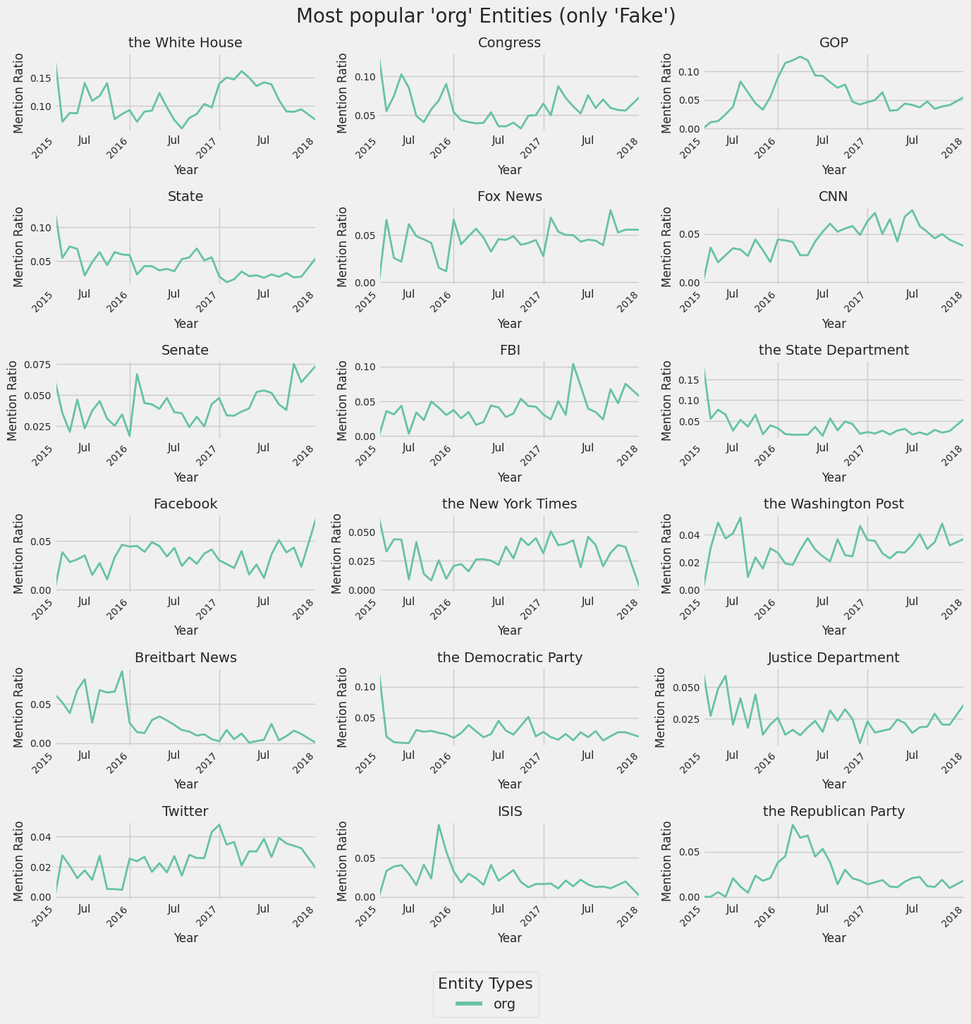

Looking at specifically only geographic and organization entities shows some interesting patterns as well.

#### Summary Of Entities by Target Variable

This show the ratio of specific entity tags based on whether they were used more frequently in "Fake" vs Reuters articles.

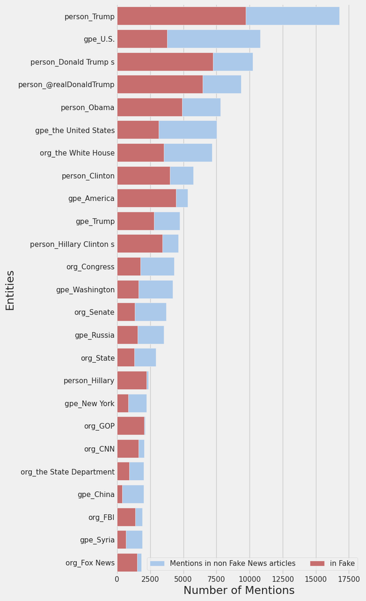

#### Sentiment:

````
polarity metric is a measure of the overall sentiment of a given text. The value of polarity ranges from -1.0 to 1.0:

A polarity of -1.0 indicates an extremely negative sentiment.
A polarity of 1.0 indicates an extremely positive sentiment.
A polarity of 0 represents a neutral sentiment.```
````

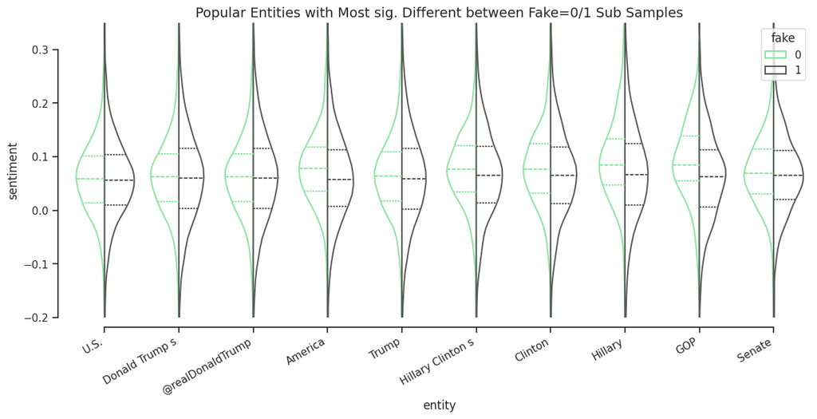

There isn't a huge different in most cases but we can see that e.g. that fake news articles that mention Hillary Clinton tend to have a slightly more negative sentiment than non-fake news ones. While this is not as clear for Trump.

One signfinificant issue is that we're calculated the sentiment for the entire text, instead we should be looking only at sentences or segments surrounding specific entities.

### Embedings and Building a DNN Model

A significant problem with the dataset is that it's much too easy to build a robust model while using raw data because a model would significantly overfit on:

- Articles often include the name of the news agency that published it or very specific patterns e.g. Reuters reports always start in exactly the same way.

Due to all the issues analyzed previously we don't believe that it's possible to build a robust model that could provide any meanginful value by using the dataset directly (or in any way...):

##### Non-representivie dataset

The main issue is that almost all "non-fake" news articles are published by Reuters while the "fake" come from various different sources:

| fake | Reuters % | N Reuters articles | N non-Reuters articles |
| --- | --- | --- | --- |
| 0 | 0.997980 | 17296 | 35 |
| 1 | 0.014434 | 267 | 18231 |

This means that the legitimate news samples are highly unrrepresntive and only reflect the style of language etc. used by a single organization that gennerally only tends to publish realtivelly unbiased factual news reports with minimal analysis or opinions.

It's likely that other sources (even the ones which have published the "fake news" articles in this dataset) publish at least some "non-fake" stories/articles even though they might be significantly more biased or use a language that's much harder to discern from fake news.

Effectively this means that any model we build will only be able to classify whether an article was published by Retuers or not (i.e. the model will struggle with corecctly classifying any "non-fake" articles written by Reuters".

#### Annomyizing text samples

Therefore we chose to focus exclusively on the style and structure of all articles instead of their specific content when preparing inputs for our DNN (BERT based) model:

#### Example of preprocessing pipeline:

WASHINGTON (Reuters) - Ohio Governor John Kasich, who has staked his Republican presidential campaign on the upcoming contests in the Midwest, said on Monday he would not need a lead in the delegate count before his party's convention to win the nomination, according to media reports. "In order to be the nominee, you have to have a certain number of votes," Kasich said after a town hall in Monroe, Michigan, which holds its presidential primary on Tuesday. "You've got to win. You don't just say, 'Well, I have more than anybody else, therefore I'm in,'" Kasich said, according to the Washington Post. Kasich, who is rising in some opinion polls to compete with Ted Cruz for second place in Michigan's Republican primary, has embraced the idea of a brokered convention to choose the nominee if no one gets a majority of delegates in the nominating contests for the Nov. 8 election. New York billionaire Donald Trump is at the top of the dwindling Republican pack with the highest delegate count, but victories on Saturday by Cruz, the U.S. senator from Texas, cut into his lead. Kasich trails all his rivals, including U.S. Senator Marco Rubio of Florida, in delegates won [...]

First We've started by:

- Removing all sentences that include the word `Reuters` since even if we remove/replace the name these article are still very easy to detect because they always start with a very specific pattern.

"In order to be the nominee, you have to have a certain number of votes," Kasich said after a town hall in Monroe, Michigan, which holds its presidential primary on Tuesday. "You've got to win. You don't just say, 'Well, I have more than anybody else, therefore I'm in,'" Kasich said, according to the Washington Post. Kasich, who is rising in some opinion polls to compete with Ted Cruz for second place in Michigan's Republican primary, has embraced the idea of a brokered convention to choose the nominee if no one gets a majority of delegates in the nominating contests for the Nov. 8 election. New York billionaire Donald Trump is at the top of the dwindling Republican pack with the highest delegate count, but victories on Saturday by Cruz, the U.S. senator from Texas, cut into his lead. Kasich trails all his rivals, including U.S. Senator Marco Rubio of Florida, in delegates won [...]

Since specific proper names (persons, organizations, regions) are very highly associated with fake news articles not because of their inherent attributes due to when the article was published we've removed all proper nouns (specifically "entities" detected by Spacy) and just replaced them with their type:

1. Each entity is replaced with it's specific tag, e.g. "Kasich" becomes [PERSON0]
2. Inside the anonymized sample the same enitity retains the same id (e.g. "Kassich is always [PERSON0], Michigan is always "[GPE2]" etc.

The preprocssesing pipeline supports other more complex modes, like assinging unique keywords or hashes (unique to each sample) to each entity so that e.g. 'PERSON{N}' etc. wouldn't be repeated in each article, however we didn't notice a signficant different in classification performance.

Example sample after full transformations:

In order to be the nominee, you have to have a certain number of votes," [PERSON0] said after a town hall in [GPE1], [GPE2], which holds its presidential primary on [DATE3]. "You've got to win. You don't just say, 'Well, I have more than anybody else, therefore I'm in,'" [PERSON0] said, according to [ORG4]. [PERSON0], who is rising in some opinion polls to compete with [PERSON5] for second place in [GPE2]'s [ORG6] primary, has embraced the idea of a brokered convention to choose the nominee if no one gets a majority of delegates in the nominating contests for the [DATE7] election. [GPE8] billionaire [PERSON9] is at the top of the dwindling [ORG6] pack with the highest delegate count, but victories on [DATE10] by [PERSON11], the [GPE12] [ORG13] from [GPE14], cut into his lead. [PERSON0] trails all his rivals, including [GPE12] [ORG13] [PERSON15] of [GPE16], in delegates won [...]

### Generating and Analyzing Embeddings

We've generated emebddings using BERT (without any finetuning) for all the anonymized sample (embeddings for the raw samples and the intermediate ones (all sentences mentioning "Reuters" are removed while other entity names are retained.

[output not shown]

#### Clustering

UMAP and HDBSCAN were used to cluster the embeddings (512 tokens, with remainder of the text truncated).

The specific number of UMAP components (and HDBSCAN scan parameters) were by hyperparameter tuning and targetting these specific metrics:

- Silhouette Score
- Calinski-Harabasz score
- Penalty based on proportion of noise (samples not included in any cluster)

[interactive chart not shown]

Removing the first sentence introduced signficant amounts of noise acluster do not match target variable to such a large extent.

```
NMI (Normalized Mutual Information) measures the amount of information shared between the clustering results and the true labels. It quantifies how well the clustering aligns with the actual categories, accounting for different numbers of clusters.

ARI (Adjusted Rand Index) assesses the similarity between the clustering and true labels, adjusting for chance agreement. It provides a measure of accuracy for the clustering compared to the ground truth, with correction for random labeling.

Both metrics help evaluate clustering performance, with higher values indicating better alignment between the clustering results and the true labels.
```

*Our goal isn't to neccesarily use this as replacement for a supervised classification model,* instead we want to verify our assumption that a model that uses raw unmodified article text as inputs couldn't possibly be robust or useful because it would just overfit on specific keywoards or pattern (especially those used in Reuters news reports).

i.e. if an unsupervised "mode" like HDBSCAN ends up clustering BERT embeddings in clusters that strongly overlap with the target variable that's probably the case.

### Topic Analysis

Our assumption is that these clusters represent more finegrained clusters based on topic or other attributes besides being split around the target variable.

1. TF-IDF (Term Frequency-Inverse Document Frequency) identifies potentially important terms in each cluster.
2. Chi-squared analysis then determines which of these terms are statistically distinctive for each cluster.
3. Named entity recognition extracts key actors, organizations, and locations from the text.

### Cluster Centroid Summarization

This technique generates three key outputs for each text cluster:

Representative text: The document whose embedding is closest to the cluster's centroid (mean embedding), measured by cosine similarity. Keyword list: The most frequent terms in the cluster, excluding stop words, typically 10-20 words ranked by frequency. Cluster size: The number of documents in the cluster.

To use this technique:

Calculate the centroid (mean embedding) for each cluster. Find the document closest to each centroid using cosine similarity. Aggregate all texts in each cluster and extract frequent terms. Count the documents in each cluster.

Interpretation:

Representative text: Provides a concrete example of the cluster's content. Compare across clusters to understand dataset themes. Keywords: Highlight common topics or entities. Look for unexpected combinations or variations between clusters.